# Calcul scientifique 2017

## Pour la creation et manipulation de matrices et vecteurs, nous pouvons utiliser les modules `scipy` ou `numpy`.

```python
import scipy as sp
# Ou import numpy as np
```

Pour créer des vecteurs et matrices, il suffit de créer des instances de `array`.

Soit à partir de listes (pour les vecteurs) ou listes de listes (matrices).

```python
x = sp.array([1,2,3])
print x
```

```
[1 2 3]
```

```python
M = sp.array([[1,2,3],[4,5,6]])
print M
```

```
[[1 2 3]
 [4 5 6]]
```

Soit en utilisant des fonctions (comme nous l'avons fait avec `range` pour des listes).

```python
x = sp.ones(5)
M = sp.ones((3,2))
print x
print M
```

```
[ 1.  1.  1.  1.  1.]
[[ 1.  1.]
 [ 1.  1.]
 [ 1.  1.]]
```

```python
M = sp.identity(3)
N = sp.diag([1,2,3])
print M
print N
```

```
[[ 1.  0.  0.]
 [ 0.  1.  0.]
 [ 0.  0.  1.]]
[[1 0 0]
 [0 2 0]
 [0 0 3]]
```

```python
x = sp.arange(10)
y = sp.linspace(0,1,11)
print x
print y
```

```
[0 1 2 3 4 5 6 7 8 9]
[ 0.   0.1  0.2  0.3  0.4  0.5  0.6  0.7  0.8  0.9  1. ]
```

Toutes les opérations arithmétiques effectuées élément par élément, **incluant la multiplication**!

```python
print x + x
print 10 * x
```

```
[ 0  2  4  6  8 10 12 14 16 18]
[ 0 10 20 30 40 50 60 70 80 90]
```

La fonction `dot` est utilisée pour la multiplication vectorielle (entre n'importe quel pair de `array` peu import s'ils sont des matrices ou vecteurs).

```python
x = sp.array([1,2,3])
N = sp.diag([1,2,3])
print sp.dot(N, x)
```

```
[1 4 9]
```

```python
print sp.dot(N, N)
```

```
[[1 0 0]
 [0 4 0]
 [0 0 9]]
```

L'attribut `.T` permet d'obtenir la transposée.

Remarque (avancée): En fait `.T` est une méthode qui est appelée avec une syntaxe particulière sans parenthèses.

```python
M = sp.array([[1,2,3],[4,5,6]])
print M
print M.T
```

```
[[1 2 3]
 [4 5 6]]
[[1 4]
 [2 5]
 [3 6]]
```

Voici quelques méthodes utiles pour les `array`s.

```python
print M.max()
```

```
6
```

```python
print M.sum()
```

```
21
```

```python
print sp.size(x)
print M.shape
```

```
3
(2, 3)
```

Les comparateurs `>`, `==`, `<` etc sont aussi appliqués élément par élément.

```python
x = sp.array([1,2,3,4])
print x > 2.5
```

```
[False False  True  True]
```

Cela devient très utile lorsqu'on veut sélectionner des entrées d'un `array` avec la syntaxe `A[B]`.

```python
A = sp.array([[4, 1, 5], [10, 9, 8], [7, 7, 5]])
print A
B = (A > 3)
print B
print A[B]
```

```
[[ 4  1  5]
 [10  9  8]
 [ 7  7  5]]
[[ True False  True]
 [ True  True  True]
 [ True  True  True]]
[ 4  5 10  9  8  7  7  5]
```

Ou si on veut modifier certains entrées seulement. Voici un exemple où on ajoute 1 à tous les entrée plus grand que 2.5.

```python
x = sp.array([1,2,3,4])
print x
print x > 2.5
print x[x > 2.5]
x[x > 2.5] += 1
print x
```

```
[1 2 3 4]
[False False  True  True]
[3 4]
[1 2 4 5]
```

La méthode `.where` permet d'obtenir les coordonnée (plutôt que les entrées que donne les comparateurs).

```python
M = sp.rand(3,3)
print M
sp.where(M > 0.5)
```

```
[[ 0.96398971  0.30971898  0.79790582]
 [ 0.68565304  0.03439127  0.54248998]
 [ 0.62063371  0.48655713  0.12617676]]
```

```
(array([0, 0, 1, 1, 2]), array([0, 2, 0, 2, 0]))
```

```python
indices = sp.where(x > 2.5)[0]
print indices
```

```
[2 3]
```

## Tracée de courbes « scientifiques » avec `pylab`

```python
import pylab as pl
```

Pour voir le résultat des tracées dans cette page, lancer ipython ou jupyter avec `--pylab=inline`. Dans les nouvelles version, il est aussi possible de lancer d'ici:

```python
%matplotlib inline
```

### Tracée 1D

Pour tracer une sinusoide:

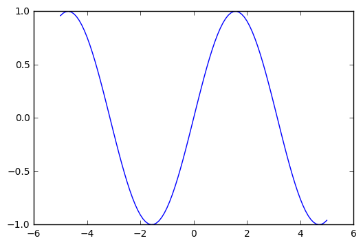

```python
x = pl.linspace(-5,5,101) # coordonnées de -5 à 5 avec 101 valeurs
y = pl.sin(x)
pl.plot(x,y) # Tracé de la courbe !
```

Pour tracer plusieurs courbes, on peut les mettre les unes à la suite des autres, par exemple :

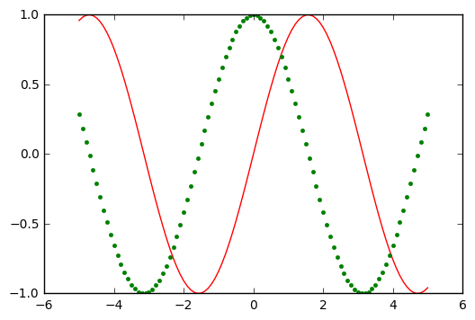

```python
pl.plot(x, y, "r-", x, pl.cos(x), "g.")
```

Pour cela on utilise `imshow(z)` ou `pcolor(x,y,z)`.

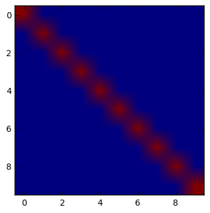

```python
z = pl.identity(10)
pl.imshow(z)   # Affiche les entrées de la matrice z en 2D
```

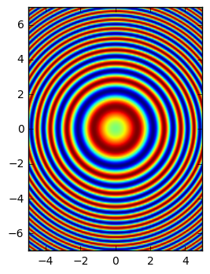

```python
x = pl.linspace(-5,5,201)
y = pl.linspace(-7,7,201)[:, pl.newaxis]
   # newaxis indique que ce vecteur est selon la 2ème dimension
z = pl.sin(x**2 + y**2)
pl.imshow(z) # Affiche l'image en 2D

pl.imshow(z, extent=(x.min(), x.max(), y.min(), y.max()))
   # On précise les coordonnées des axes
```

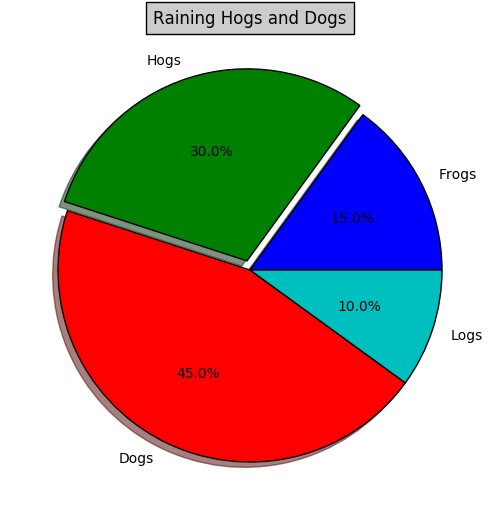

```python
import pylab as pl

pl.figure(1, figsize=(6,6))
ax = pl.axes([0.1, 0.1, 0.8, 0.8])

labels = 'Frogs', 'Hogs', 'Dogs', 'Logs'
fracs = [15,30,45, 10]
explode = (0, 0.05, 0, 0)
pl.pie(fracs, explode=explode, labels=labels, autopct='%1.1f%%',
shadow=True)
pl.title('Raining Hogs and Dogs', bbox={'facecolor':'0.8', 'pad':5})
pl.show()
```